# Primary and Secondary Analysis

## Top and Bottom Performing Cities

### Identify the top 3 and bottom 3 cities by total trips over the entire analysis period.

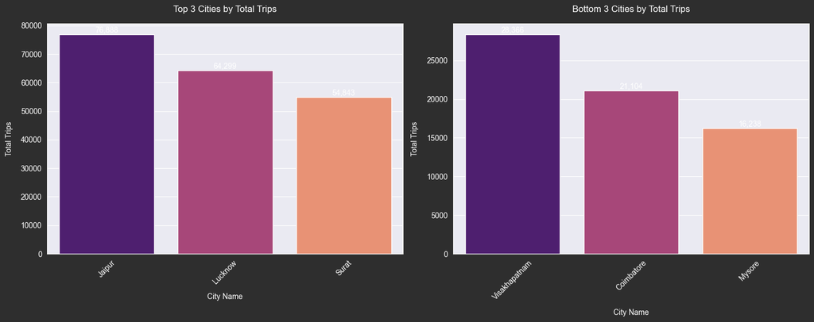

```
Top 3 Cities Analysis:
  city_name  total_trips  trip_percentage
7    Jaipur        76888            18.05
9   Lucknow        64299            15.10
2     Surat        54843            12.88

Bottom 3 Cities Analysis:
       city_name  total_trips  trip_percentage
0  Visakhapatnam        28366             6.66
8     Coimbatore        21104             4.96
4         Mysore        16238             3.81

Comparative Analysis:
Total Trips Across All Cities: 425,903
Top 3 Cities Total Trips: 196,030
Bottom 3 Cities Total Trips: 65,708
Percentage of Trips in Top 3 Cities: 46.03%
Percentage of Trips in Bottom 3 Cities: 15.43%
```

```python
import pandas as pd
import matplotlib.pyplot as plt
import seaborn as sns

# Set the style to dark background
plt.style.use('dark_background')
sns.set_style("darkgrid")

# 1. Data Import
fact_trips = pd.read_csv('../datasets/csv_files/fact_trips.csv')
dim_city = pd.read_csv('../datasets/csv_files/dim_city.csv')

# 2. Data Preparation
city_trip_summary = fact_trips.groupby('city_id').size().reset_index(name='total_trips')
city_trip_summary = city_trip_summary.merge(dim_city[['city_id', 'city_name']], on='city_id')

# 3. Top and Bottom Cities Analysis
city_trip_summary_sorted = city_trip_summary.sort_values('total_trips', ascending=False)
total_trips = city_trip_summary_sorted['total_trips'].sum()

top_3_cities = city_trip_summary_sorted.head(3).copy()
bottom_3_cities = city_trip_summary_sorted.tail(3).copy()

top_3_cities['trip_percentage'] = (top_3_cities['total_trips'] / total_trips * 100).round(2)
bottom_3_cities['trip_percentage'] = (bottom_3_cities['total_trips'] / total_trips * 100).round(2)

# 4. Visualization
plt.figure(figsize=(15, 6), facecolor='#2e2e2e')

# Bar plot for Top Cities
plt.subplot(1, 2, 1)
bars1 = sns.barplot(x='city_name', y='total_trips', data=top_3_cities, palette='magma', hue='city_name')
plt.title('Top 3 Cities by Total Trips', fontsize=12, color='white', pad=15)
plt.xticks(rotation=45, color='white')
plt.yticks(color='white')
plt.xlabel('City Name', color='white', labelpad=10)
plt.ylabel('Total Trips', color='white', labelpad=10)

# Add value labels on bars
for i, bar in enumerate(bars1.patches):
    bars1.text(bar.get_x() + bar.get_width()/2.,
              bar.get_height(),
              f'{int(bar.get_height()):,}',
              ha='center', va='bottom', color='white')

# Bar plot for Bottom Cities
plt.subplot(1, 2, 2)
bars2 = sns.barplot(x='city_name', y='total_trips', data=bottom_3_cities, palette='magma', hue='city_name')
plt.title('Bottom 3 Cities by Total Trips', fontsize=12, color='white', pad=15)
plt.xticks(rotation=45, color='white')
plt.yticks(color='white')
plt.xlabel('City Name', color='white', labelpad=10)
plt.ylabel('Total Trips', color='white', labelpad=10)

# Add value labels on bars
for i, bar in enumerate(bars2.patches):
    bars2.text(bar.get_x() + bar.get_width()/2.,
              bar.get_height(),
              f'{int(bar.get_height()):,}',
              ha='center', va='bottom', color='white')

# Adjust layout and display
plt.tight_layout()
plt.show()

# 5. Detailed Analysis
print("\033[97m")  # Set print color to white
print("Top 3 Cities Analysis:")
print(top_3_cities[['city_name', 'total_trips', 'trip_percentage']].to_string())
print("\nBottom 3 Cities Analysis:")
print(bottom_3_cities[['city_name', 'total_trips', 'trip_percentage']].to_string())

# 6. Additional Insights
print("\nComparative Analysis:")
print(f"Total Trips Across All Cities: {total_trips:,}")
print(f"Top 3 Cities Total Trips: {top_3_cities['total_trips'].sum():,}")
print(f"Bottom 3 Cities Total Trips: {bottom_3_cities['total_trips'].sum():,}")
print(f"Percentage of Trips in Top 3 Cities: {top_3_cities['trip_percentage'].sum():.2f}%")
print(f"Percentage of Trips in Bottom 3 Cities: {bottom_3_cities['trip_percentage'].sum():.2f}%")
```

#### Outcome:

- Top Performers:
  - Jaipur leads with 76,888 trips, capturing 18.05% of the market.
  - Lucknow follows with 64,299 trips, contributing 15.10%.
  - Surat secures the third spot with 54,843 trips, accounting for 12.88%.
- Underperformers:
  - Visakhapatnam records 28,366 trips, making up 6.66%.
  - Coimbatore sees 21,104 trips, representing 4.96%.
  - Mysore trails with 16,238 trips, holding 3.81%.
- Comparative Insights:
  - Total trips across all cities amount to 425,903.
  - Top 3 cities collectively account for 196,030 trips, 46.03% of the total.
  - Bottom 3 cities contribute 65,708 trips, just 15.43%.
- Strategic Implications:
  - Focus on expanding services in top-performing cities to capitalize on high demand.
  - Explore growth opportunities in underperforming cities to increase market share.
  - Tailor marketing strategies to leverage strengths in high-performing areas.

## Average Fare per Trip by City

### Calculate the average fare per trip for each city and compare it with the city’s average trip distance. Identify the cities with the highest and lowest average fare per trip to assess pricing efficiency across locations.

```
City Analysis - Sorted by Average Fare:
=========================================
       city_name  fare_amount  distance_travelled(km)
7         Jaipur       483.92                   30.02
5          Kochi       335.25                   24.07
1     Chandigarh       283.69                   23.52
0  Visakhapatnam       282.67                   22.55
4         Mysore       249.71                   16.50
6         Indore       179.84                   16.50
8     Coimbatore       166.98                   14.98
9        Lucknow       147.18                   12.51
3       Vadodara       118.57                   11.52
2          Surat       117.27                   11.00
```

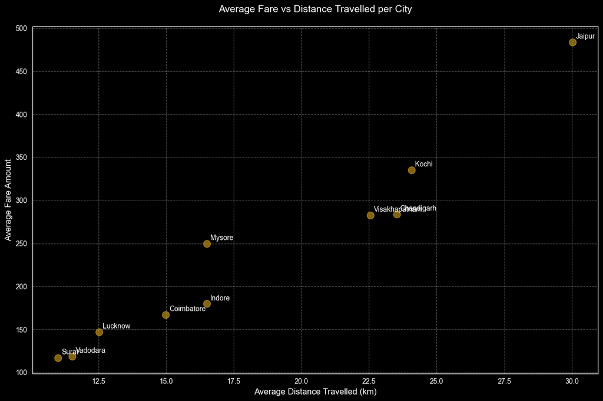

```
Fare Efficiency (Fare per Kilometer):
======================================
       city_name  fare_per_km
7         Jaipur        16.12
4         Mysore        15.14
5          Kochi        13.93
0  Visakhapatnam        12.53
1     Chandigarh        12.06
9        Lucknow        11.76
8     Coimbatore        11.15
6         Indore        10.90
2          Surat        10.66
3       Vadodara        10.29
```

```python
import pandas as pd
import matplotlib.pyplot as plt

# Set the style to dark background
plt.style.use('dark_background')

# 1. Data Import
trips_df = pd.read_csv('../datasets/csv_files/fact_trips.csv')
cities_df = pd.read_csv('../datasets/csv_files/dim_city.csv')

# calculate average fare and distance per city
city_metrics = trips_df.groupby('city_id').agg({
    'fare_amount': 'mean',
    'distance_travelled(km)': 'mean'
    }).reset_index()

# merge with city names
city_metrics = city_metrics.merge(cities_df, on='city_id', how='left')

# sort by average fare to identify highest and lowest fare cities
city_metrics = city_metrics.sort_values('fare_amount', ascending=False)

# Display results
print("\nCity Analysis - Sorted by Average Fare:")
print("=========================================")
print(city_metrics[['city_name', 'fare_amount', 'distance_travelled(km)']].round(2))

# Create a scatter plot with dark theme
plt.figure(figsize=(12, 8))
plt.scatter(city_metrics['distance_travelled(km)'], city_metrics['fare_amount'],
           color='goldenrod', s=100, alpha=0.6)

# Customize the plot
plt.xlabel('Average Distance Travelled (km)', color='white', fontsize=12)
plt.ylabel('Average Fare Amount', color='white', fontsize=12)
plt.title('Average Fare vs Distance Travelled per City', color='white', fontsize=14, pad=20)

# Add city labels to the points with white text
for i, city in enumerate(city_metrics['city_name']):
    plt.annotate(city,
                (city_metrics['distance_travelled(km)'].iloc[i], city_metrics['fare_amount'].iloc[i]),
                color='white',
                xytext=(5, 5),
                textcoords='offset points',
                fontsize=10)

# Customize grid and spines
plt.grid(True, linestyle='--', alpha=0.3)
plt.tick_params(colors='white')

# Adjust layout and display
plt.tight_layout()
plt.show()

# Calculate fare per kilometer for each city
city_metrics['fare_per_km'] = city_metrics['fare_amount'] / city_metrics['distance_travelled(km)']
print("\nFare Efficiency (Fare per Kilometer):")
print("======================================")
print(city_metrics[['city_name', 'fare_per_km']].sort_values('fare_per_km', ascending=False).round(2))
```

#### Outcome:

- **Top Performers by Average Fare:**
  - Jaipur leads with an average fare of ₹483.92 over 30.02 km.
  - Kochi follows with ₹335.25 over 24.07 km.
  - Chandigarh ranks third with ₹283.69 over 23.52 km.
- **Fare Efficiency (Fare per Kilometer):**
  - Jaipur achieves the highest fare efficiency at ₹16.12 per km.
  - Mysore follows closely with ₹15.14 per km.
  - Kochi maintains a strong position with ₹13.93 per km.
- **Strategic Insights:**
  - Jaipur's high fare and efficiency suggest a premium market position.
  - Kochi and Chandigarh show balanced fare and distance metrics, indicating stable demand.
  - Focus on optimizing services in cities with lower fare efficiency to enhance profitability.

## Average Rating by City and Passanger Type

### Calculate the average passenger and driver ratings for each city, segmented by passenger type (new vs. repeat). Identify cities with the highest and lowest average ratings.

```
Detailed Ratings by City and Passenger Type:
===========================================
               new_passenger_rating  repeated_passenger_rating  new_driver_rating  repeated_driver_rating
city_name
Chandigarh                     8.49                       7.49               7.99                    7.47
Coimbatore                     8.49                       7.48               7.99                    7.48
Indore                         8.49                       7.47               7.97                    7.48
Jaipur                         8.99                       7.99               8.99                    8.98
Kochi                          8.99                       8.00               8.99                    8.99
Lucknow                        7.98                       5.99               6.99                    6.49
Mysore                         8.98                       7.98               8.98                    8.97
Surat                          7.98                       6.00               6.99                    6.48
Vadodara                       7.98                       5.98               7.00                    6.48
Visakhapatnam                  8.98                       7.99               8.98                    8.99

Top 3 Cities by Passenger Rating:
================================
           passenger_rating
city_name
Kochi                  8.50
Jaipur                 8.49
Mysore                 8.48

Bottom 3 Cities by Passenger Rating:
==================================
           passenger_rating
city_name
Lucknow                6.98
Vadodara               6.98
Surat                  6.99
```

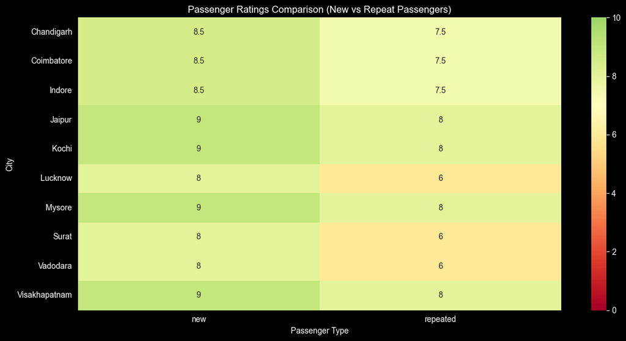

```python
import pandas as pd
import matplotlib.pyplot as plt
import seaborn as sns

# Set the style for dark theme
plt.style.use('dark_background')

# Data Import
fact_trips = pd.read_csv('../datasets/csv_files/fact_trips.csv')
dim_city = pd.read_csv('../datasets/csv_files/dim_city.csv')

# Merge trips with city information
trips_analysis = fact_trips.merge(dim_city, on='city_id')

# Calculate average ratings by city and passenger type
rating_metrics = trips_analysis.groupby(['city_name', 'passenger_type']).agg({
    'passenger_rating': 'mean',
    'driver_rating': 'mean'
}).round(2)

# Reset index for easier manipulation
rating_metrics = rating_metrics.reset_index()

# 1. Create detailed ratings table
print("\nDetailed Ratings by City and Passenger Type:")
print("===========================================")
# Pivot the data for better presentation
detailed_ratings = rating_metrics.pivot(index='city_name',
                                      columns='passenger_type',
                                      values=['passenger_rating', 'driver_rating'])
detailed_ratings.columns = [f'{col[1]}_{col[0]}' for col in detailed_ratings.columns]
print(detailed_ratings.to_string())

# 2. Create highest and lowest rated cities tables
city_overall = rating_metrics.groupby('city_name').agg({
    'passenger_rating': 'mean',
    'driver_rating': 'mean'
}).round(2)

print("\nTop 3 Cities by Passenger Rating:")
print("================================")
top_3_df = city_overall.nlargest(3, 'passenger_rating')[['passenger_rating']]
print(top_3_df.to_string())

print("\nBottom 3 Cities by Passenger Rating:")
print("==================================")
bottom_3_df = city_overall.nsmallest(3, 'passenger_rating')[['passenger_rating']]
print(bottom_3_df.to_string())

# Create a heatmap to visualize ratings
plt.figure(figsize=(12, 6))
rating_comparison = rating_metrics.pivot(index='city_name',
                                      columns='passenger_type',
                                      values='passenger_rating')
sns.heatmap(rating_comparison, annot=True, cmap='RdYlGn', center=7, vmin=0, vmax=10)
plt.title('Passenger Ratings Comparison (New vs Repeat Passengers)')
plt.xlabel('Passenger Type')
plt.ylabel('City')
plt.tight_layout()
plt.show()
```

#### Outcome:

- **Top Performers by Passenger Rating:**
  - Kochi excels with a passenger rating of 8.50.
  - Jaipur follows closely with a rating of 8.49.
  - Mysore ranks third with a rating of 8.48.
- **Underperformers by Passenger Rating:**
  - Lucknow, Vadodara, and Surat share similar lower ratings around 6.98 to 6.99.
- **Detailed Insights:**
  - New passengers generally rate higher than repeat passengers across cities.
  - Jaipur and Kochi maintain high ratings for both passenger and driver satisfaction.
  - Lucknow and Surat show room for improvement in both passenger and driver ratings.
- **Strategic Implications:**
  - Leverage high ratings in Kochi and Jaipur to attract more customers.
  - Implement targeted strategies in underperforming cities to boost satisfaction.
  - Enhance driver training and service quality to improve overall ratings.

## Peak and Low Demand Months by City

### Foreach city, identify the month with the highest total trips (peak demand) and the month with the lowest total trips (low demand). This analysis will help Goodcabs understand seasonal patterns and adjust resources accordingly.

```
Peak and Low Demand Months by City:
+---------------+------------+------------+-----------+-----------+
|     City      | Peak Month | Peak Trips | Low Month | Low Trips |
+---------------+------------+------------+-----------+-----------+
|  Chandigarh   |  February  |   7,387    |   April   |   5,566   |
|  Coimbatore   |   March    |   3,680    |   June    |   3,158   |
|    Indore     |    May     |   7,787    |   June    |   6,288   |
|    Jaipur     |  February  |   15,872   |   June    |   9,842   |
|     Kochi     |    May     |   10,014   |   June    |   6,399   |
|    Lucknow    |  February  |   12,060   |    May    |   9,705   |
|    Mysore     |    May     |   3,007    |  January  |   2,485   |
|     Surat     |   April    |   9,831    |  January  |   8,358   |
|   Vadodara    |   April    |   5,941    |   June    |   4,685   |
| Visakhapatnam |   April    |   4,938    |  January  |   4,468   |
+---------------+------------+------------+-----------+-----------+
```

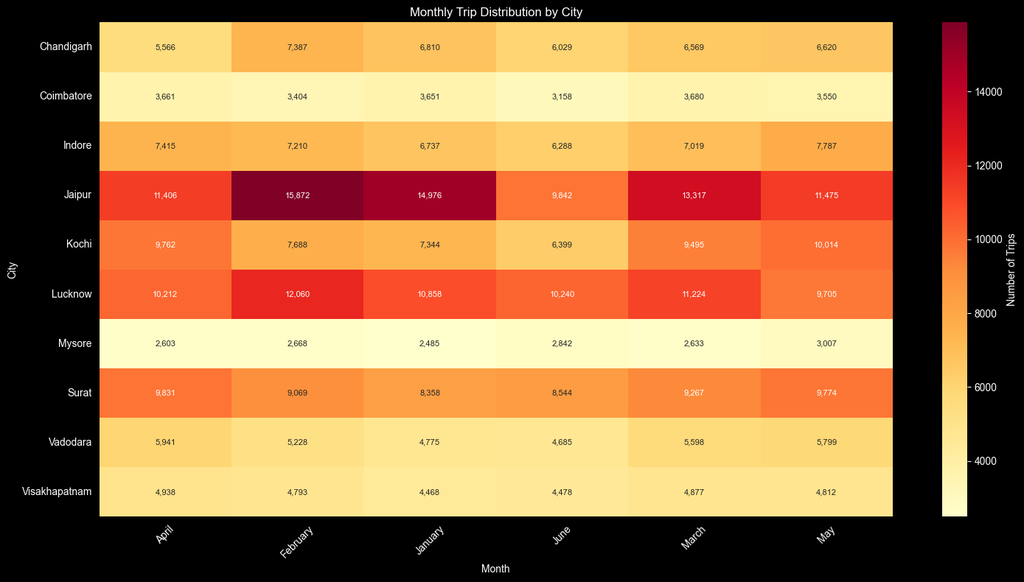

```python
import pandas as pd
import matplotlib.pyplot as plt
import seaborn as sns
from tabulate import tabulate

# Set the style for dark theme
plt.style.use('dark_background')

# Data Import
fact_trips = pd.read_csv('../datasets/csv_files/fact_trips.csv')
dim_city = pd.read_csv('../datasets/csv_files/dim_city.csv')
dim_date = pd.read_csv('../datasets/csv_files/dim_date.csv')

# Merge trips with city and date information
trips_analysis = fact_trips.merge(dim_city, on='city_id').merge(dim_date[['date', 'month_name', 'start_of_month']], on='date')

# Calculate monthly trips for each city
monthly_trips = trips_analysis.groupby(['city_name', 'start_of_month', 'month_name'])['trip_id'].count().reset_index()
monthly_trips.columns = ['city_name', 'start_of_month', 'month_name', 'total_trips']

# Find peak and low demand months for each city
peak_low_demand = monthly_trips.groupby('city_name').agg({
    'total_trips': ['idxmax', 'idxmin']
}).reset_index()

# Get the actual months and trip counts
results = []
for city in peak_low_demand['city_name']:
    city_data = monthly_trips[monthly_trips['city_name'] == city]
    peak_idx = city_data['total_trips'].idxmax()
    low_idx = city_data['total_trips'].idxmin()

    results.append({
        'City': city,
        'Peak Month': city_data.loc[peak_idx, 'month_name'],
        'Peak Trips': f"{city_data.loc[peak_idx, 'total_trips']:,}",
        'Low Month': city_data.loc[low_idx, 'month_name'],
        'Low Trips': f"{city_data.loc[low_idx, 'total_trips']:,}"
    })

results_df = pd.DataFrame(results)

# Print results in tabular format
print("\nPeak and Low Demand Months by City:")
print(tabulate(results_df, headers='keys', tablefmt='pretty', showindex=False))

# Create heatmap
plt.figure(figsize=(15, 8))
pivot_data = monthly_trips.pivot(index='city_name', columns='month_name', values='total_trips')
sns.heatmap(pivot_data, annot=True, fmt=',', cmap='YlOrRd',
            cbar_kws={'label': 'Number of Trips'},
            annot_kws={'size': 8})
plt.title('Monthly Trip Distribution by City')
plt.xlabel('Month')
plt.ylabel('City')
plt.xticks(rotation=45)
plt.tight_layout()
plt.show()
```

#### Outcome:

- **Peak Demand Insights:**
  - Jaipur experiences peak demand in February with 15,872 trips.
  - Kochi and Indore also see high demand in May with 10,014 and 7,787 trips, respectively.
  - Lucknow peaks in February with 12,060 trips, indicating a strong start to the year.
- **Low Demand Insights:**
  - Jaipur and Kochi face low demand in June, with trips dropping to 9,842 and 6,399, respectively.
  - Mysore and Visakhapatnam see the lowest demand in January, with trips at 2,485 and 4,468.
- **Comparative Insights:**
  - February and May are generally high-demand months across multiple cities.
  - June appears to be a low-demand month for many cities, suggesting seasonal trends.
- **Strategic Implications:**
  - Enhance marketing efforts in peak months to maximize revenue.
  - Develop strategies to boost demand during low months, possibly through promotions.
  - Tailor city-specific strategies based on unique demand patterns.

## Weekend vs. Weekday Trip Demand by City

### Compare the total trips taken on weekdays versus weekends for each city over the six-month period. Identify cities with a strong preference for either weekend or weekday trips to understand demand variations.

```
Trip Distribution by Day Type for Each City:
===========================================
day_type      Weekday Weekend   Total Weekday_Ratio Weekend_Ratio
city_name
Chandigarh     19,914  19,067  38,981        51.09%        48.91%
Coimbatore     12,576   8,528  21,104        59.59%        40.41%
Indore         21,198  21,258  42,456        49.93%        50.07%
Jaipur         32,491  44,397  76,888        42.26%        57.74%
Kochi          22,915  27,787  50,702         45.2%         54.8%
Lucknow        49,617  14,682  64,299        77.17%        22.83%
Mysore          6,424   9,814  16,238        39.56%        60.44%
Surat          37,793  17,050  54,843        68.91%        31.09%
Vadodara       20,310  11,716  32,026        63.42%        36.58%
Visakhapatnam  15,100  13,266  28,366        53.23%        46.77%
```

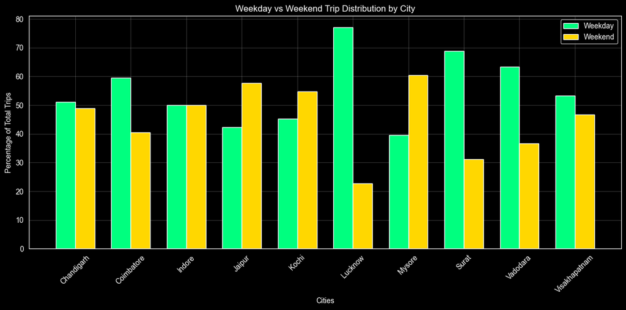

```python
import pandas as pd
import matplotlib.pyplot as plt
import seaborn as sns

# Set the style for dark theme
plt.style.use('dark_background')

# Data Import
fact_trips = pd.read_csv('../datasets/csv_files/fact_trips.csv')
dim_city = pd.read_csv('../datasets/csv_files/dim_city.csv')
dim_date = pd.read_csv('../datasets/csv_files/dim_date.csv')

# Merge data
trips_analysis = fact_trips.merge(dim_city, on='city_id').merge(dim_date[['date', 'day_type']], on='date')

# Calculate trips by city and day type
day_type_analysis = trips_analysis.groupby(['city_name', 'day_type'])['trip_id'].count().reset_index()
day_type_pivot = day_type_analysis.pivot(index='city_name', columns='day_type', values='trip_id')
day_type_pivot['Total'] = day_type_pivot['Weekday'] + day_type_pivot['Weekend']
day_type_pivot['Weekday_Ratio'] = (day_type_pivot['Weekday'] / day_type_pivot['Total'] * 100).round(2)
day_type_pivot['Weekend_Ratio'] = (day_type_pivot['Weekend'] / day_type_pivot['Total'] * 100).round(2)

# Format the numbers
formatted_pivot = day_type_pivot.copy()
formatted_pivot['Weekday'] = formatted_pivot['Weekday'].apply(lambda x: f"{x:,}")
formatted_pivot['Weekend'] = formatted_pivot['Weekend'].apply(lambda x: f"{x:,}")
formatted_pivot['Total'] = formatted_pivot['Total'].apply(lambda x: f"{x:,}")
formatted_pivot['Weekday_Ratio'] = formatted_pivot['Weekday_Ratio'].apply(lambda x: f"{x}%")
formatted_pivot['Weekend_Ratio'] = formatted_pivot['Weekend_Ratio'].apply(lambda x: f"{x}%")

# Print results in tabular format
print("\nTrip Distribution by Day Type for Each City:")
print("===========================================")
print(formatted_pivot.to_string())

# Create visualization
plt.figure(figsize=(12, 6))
day_type_ratios = pd.DataFrame({
    'City': day_type_pivot.index,
    'Weekday Ratio': day_type_pivot['Weekday_Ratio'],
    'Weekend Ratio': day_type_pivot['Weekend_Ratio']
})

x = range(len(day_type_ratios))
width = 0.35

plt.bar(x, day_type_ratios['Weekday Ratio'], width, label='Weekday', color='#00FF7F')
plt.bar([i + width for i in x], day_type_ratios['Weekend Ratio'], width, label='Weekend', color='#FFD700')

plt.xlabel('Cities')
plt.ylabel('Percentage of Total Trips')
plt.title('Weekday vs Weekend Trip Distribution by City')
plt.xticks([i + width/2 for i in x], day_type_ratios['City'], rotation=45)
plt.legend()

plt.grid(True, alpha=0.2)
plt.tight_layout()
plt.show()
```

#### Outcome:

- **Weekday Dominance:**
  - Lucknow shows a strong weekday preference with 77.17% of trips.
  - Surat and Vadodara also favor weekdays, with 68.91% and 63.42% respectively.
- **Weekend Preference:**
  - Jaipur and Mysore have a higher weekend ratio, with 57.74% and 60.44%.
  - Kochi also leans towards weekends, with 54.8% of trips.
- **Balanced Cities:**
  - Indore displays a balanced distribution, with a slight weekend preference at 50.07%.
  - Visakhapatnam and Chandigarh are almost evenly split between weekdays and weekends.
- **Strategic Implications:**
  - Tailor marketing campaigns to align with city-specific day preferences.
  - Enhance service availability during peak days to maximize efficiency.
  - Explore promotional opportunities to boost demand on less busy days.

## Repeat Passanger Frequency and City Contribution Analysis

### Analyse the frequency of trips taken by repeat passengers in each city (e.g. % of repeat passengers taking 2 trips, 3 trips, etc.). Identify which cities contribute most to higher trip frequencies among repeat passengers, and examine if there are distinguishable patterns between tourism-focused and business-focused cities.

```
Cities Ranked by High-Frequency Repeat Passengers (5+ trips):
=======================================================
               Total Repeat Passengers  High Freq Passengers  High Freq %
city_name
Vadodara                          4346                  2583        59.43
Surat                             8638                  5133        59.42
Lucknow                           9597                  5698        59.37
Coimbatore                        2551                  1490        58.41
Chandigarh                        5070                  1658        32.70
Indore                            7216                  2134        29.57
Jaipur                            9682                  1647        17.01
Kochi                             7626                  1233        16.17
Mysore                            1477                   208        14.08
Visakhapatnam                     5108                   705        13.80


Detailed Trip Frequency Distribution by City (%):
===============================================
trip_number      2     3     4     5     6     7     8     9     10
city_name
Chandigarh     5.39  3.21  2.62  2.04  1.24  0.92  0.58  0.39  0.30
Coimbatore     1.87  2.47  2.59  3.44  2.94  1.74  1.03  0.39  0.20
Indore         5.72  3.78  2.23  1.72  1.14  0.87  0.55  0.40  0.25
Jaipur         8.36  3.45  2.02  1.05  0.69  0.42  0.32  0.20  0.16
Kochi          7.94  4.06  1.97  1.08  0.65  0.35  0.28  0.20  0.14
Lucknow        1.61  2.46  2.70  3.07  3.36  1.89  1.07  0.32  0.19
Mysore         8.12  4.08  2.12  0.97  0.68  0.30  0.24  0.09  0.08
Surat          1.63  2.38  2.76  3.29  3.07  1.98  1.04  0.29  0.23
Vadodara       1.64  2.36  2.75  3.01  3.18  2.14  0.96  0.34  0.27
Visakhapatnam  8.54  4.16  1.66  0.90  0.53  0.33  0.23  0.15  0.16
```

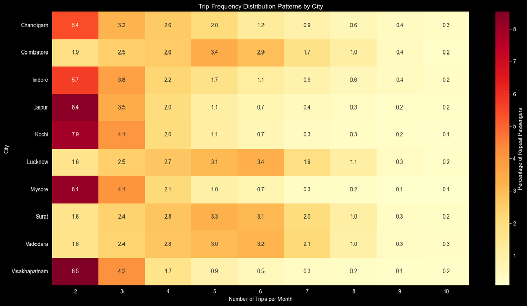

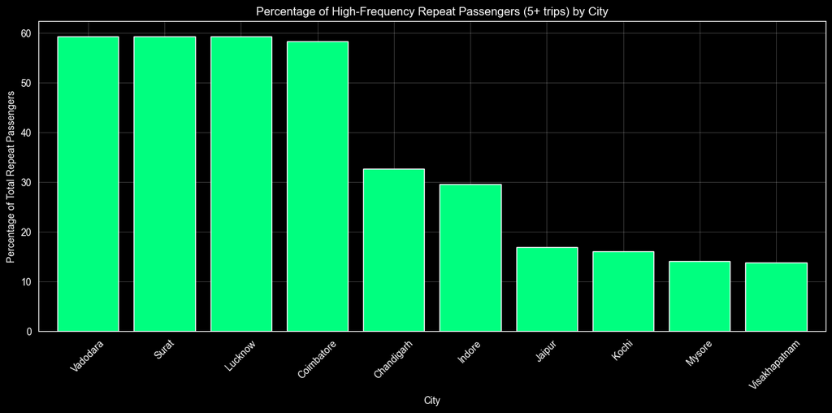

```python
import pandas as pd
import matplotlib.pyplot as plt
import seaborn as sns

# Set the style for dark theme
plt.style.use('dark_background')

# Data Import
repeat_dist = pd.read_csv('../datasets/csv_files/dim_repeat_trip_distribution.csv')
dim_city = pd.read_csv('../datasets/csv_files/dim_city.csv')

# Merge data
trip_freq = repeat_dist.merge(dim_city, on='city_id')

# Extract numeric trip count and sort by it
trip_freq['trip_number'] = trip_freq['trip_count'].str.extract(r'(\d+)').astype(int)
trip_freq = trip_freq.sort_values('trip_number')

# Calculate total repeat passengers per city
city_totals = trip_freq.groupby('city_name')['repeat_passenger_count'].sum().reset_index()

# Calculate percentage distribution
trip_freq_pct = trip_freq.merge(city_totals, on='city_name', suffixes=('', '_total'))
trip_freq_pct['percentage'] = (trip_freq_pct['repeat_passenger_count'] /
                             trip_freq_pct['repeat_passenger_count_total'] * 100).round(2)

# Analyze high frequency patterns (5 or more trips)
high_freq_analysis = trip_freq_pct[trip_freq_pct['trip_number'] >= 5].groupby('city_name').agg({
    'repeat_passenger_count': 'sum',
    'repeat_passenger_count_total': 'first'
}).assign(
    high_freq_percentage=lambda x: (x['repeat_passenger_count'] / x['repeat_passenger_count_total'] * 100).round(2)
).sort_values('high_freq_percentage', ascending=False)

# Print results
print("\nCities Ranked by High-Frequency Repeat Passengers (5+ trips):")
print("=======================================================")
high_freq_result = pd.DataFrame({
    'Total Repeat Passengers': high_freq_analysis['repeat_passenger_count_total'],
    'High Freq Passengers': high_freq_analysis['repeat_passenger_count'],
    'High Freq %': high_freq_analysis['high_freq_percentage']
})
print(high_freq_result.to_string())

# Create detailed frequency distribution table
freq_dist = trip_freq_pct.pivot_table(
    index='city_name',
    columns='trip_number',
    values='percentage',
    aggfunc='mean'
).round(2)

print("\n\nDetailed Trip Frequency Distribution by City (%):")
print("===============================================")
print(freq_dist.to_string())

# Visualization of trip frequency patterns
plt.figure(figsize=(15, 8))
sns.heatmap(freq_dist,
            annot=True,
            fmt='.1f',
            cmap='YlOrRd',
            cbar_kws={'label': 'Percentage of Repeat Passengers'})

plt.title('Trip Frequency Distribution Patterns by City')
plt.xlabel('Number of Trips per Month')
plt.ylabel('City')
plt.tight_layout()
plt.show()

# Bar plot focusing on high-frequency passengers
plt.figure(figsize=(12, 6))
high_freq_analysis['high_freq_percentage'].plot(kind='bar',
                                              color='#00FF7F',
                                              width=0.8)
plt.title('Percentage of High-Frequency Repeat Passengers (5+ trips) by City')
plt.xlabel('City')
plt.ylabel('Percentage of Total Repeat Passengers')
plt.grid(True, alpha=0.2)
plt.xticks(rotation=45)
plt.tight_layout()
plt.show()
```

#### Outcome:

- **Top Performers in High-Frequency Repeat Passengers:**
  - Vadodara leads with 59.43% of repeat passengers making 5+ trips.
  - Surat closely follows with 59.42%.
  - Lucknow ranks third with 59.37%.
- **Underperformers in High-Frequency Repeat Passengers:**
  - Visakhapatnam and Mysore have the lowest percentages, at 13.80% and 14.08% respectively.
  - Kochi and Jaipur also show lower engagement with 16.17% and 17.01%.
- **Trip Frequency Insights:**
  - Cities like Vadodara and Surat show strong engagement in higher trip numbers.
  - Mysore and Visakhapatnam have a higher percentage of passengers making fewer trips.
- **Strategic Implications:**
  - Encourage loyalty programs in top-performing cities to maintain high repeat rates.
  - Investigate barriers to higher trip frequencies in underperforming cities.
  - Tailor marketing efforts to convert occasional users into frequent passengers.

## Monthly Target Achievement Analysis for Key Metrics

### Foreach city, evaluate monthly performance against targets for total trips, new passengers, and average passenger ratings from targets_db. Determine if each metric met, exceeded, or missed the target, and calculate the percentage difference. Identify any consistent patterns in target achievement, particularly across tourism versus business-focused cities.

```
Monthly Performance Against Targets by City:
===========================================
         City  Trips_Target  Trips_Actual  Trips_Diff% Trips_Status  NewPass_Target  NewPass_Actual  NewPass_Diff% NewPass_Status  Rating_Target  Rating_Actual  Rating_Diff% Rating_Status
   Chandigarh          6500          6496        -0.05          Met            3500            3151          -9.96         Missed           8.00           7.93         -0.83           Met
   Coimbatore          3500          3517         0.50          Met            1250            1419          13.52       Exceeded           8.25           7.86         -4.69           Met
       Indore          7250          7076        -2.40          Met            2350            2477           5.41       Exceeded           8.00           7.80         -2.56           Met
       Jaipur         11250         12814        13.91     Exceeded            9000            7642         -15.08         Missed           8.25           8.51          3.21           Met
        Kochi          8250          8450         2.43          Met            4500            4402          -2.16            Met           8.50           8.47         -0.39           Met
      Lucknow         12000         10716       -10.70       Missed            2600            2710           4.23            Met           7.25           6.50        -10.28        Missed
       Mysore          2250          2706        20.28     Exceeded            2000            1946          -2.66            Met           8.50           8.64          1.69           Met
        Surat          9500          9140        -3.78          Met            1750            1937          10.72       Exceeded           7.00           6.41         -8.40        Missed
     Vadodara          6250          5337       -14.60       Missed            1650            1687           2.29            Met           7.50           6.59        -12.16        Missed
Visakhapatnam          4750          4727        -0.47          Met            2250            2124          -5.58         Missed           8.50           8.40         -1.22           Met
```

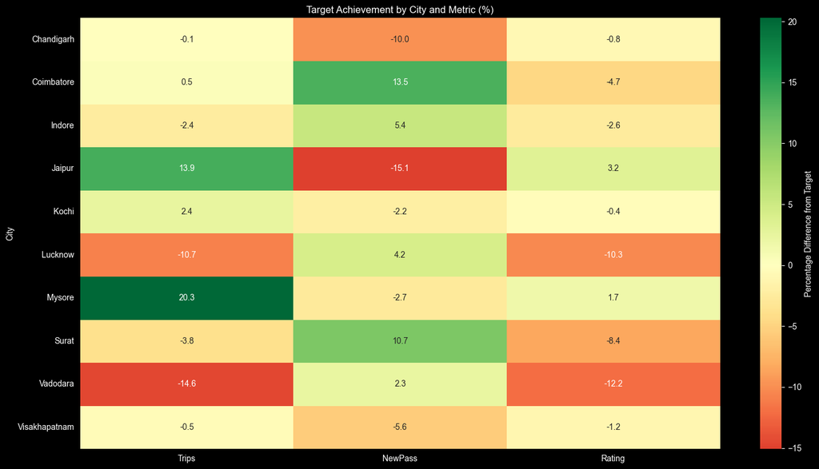

```python
import pandas as pd
import matplotlib.pyplot as plt
import seaborn as sns

# Set the style for dark theme
plt.style.use('dark_background')

# Data Import
fact_trips = pd.read_csv('../datasets/csv_files/fact_trips.csv')
fact_passenger = pd.read_csv('../datasets/csv_files/fact_passenger_summary.csv')
dim_city = pd.read_csv('../datasets/csv_files/dim_city.csv')
dim_date = pd.read_csv('../datasets/csv_files/dim_date.csv')
target_trips = pd.read_csv('../datasets/csv_files/monthly_target_trips.csv')
target_passengers = pd.read_csv('../datasets/csv_files/monthly_target_new_passengers.csv')
target_ratings = pd.read_csv('../datasets/csv_files/city_target_passenger_rating.csv')

# Calculate actual metrics
# 1. Monthly trips by city
actual_trips = fact_trips.groupby(['city_id', 'date'])['trip_id'].count().reset_index()
actual_trips = actual_trips.merge(dim_date[['date', 'start_of_month']], on='date')
monthly_trips = actual_trips.groupby(['city_id', 'start_of_month'])['trip_id'].sum().reset_index()

# 2. Monthly ratings by city
monthly_ratings = fact_trips.groupby(['city_id', 'date'])['passenger_rating'].mean().reset_index()
monthly_ratings = monthly_ratings.merge(dim_date[['date', 'start_of_month']], on='date')
monthly_ratings = monthly_ratings.groupby(['city_id', 'start_of_month'])['passenger_rating'].mean().round(2).reset_index()

# Compare with targets
def calculate_performance(actual, target):
    diff = ((actual - target) / target * 100).round(2)
    if diff < -5:
        status = 'Missed'
    elif diff > 5:
        status = 'Exceeded'
    else:
        status = 'Met'
    return diff, status

# Combine actual vs target
performance_data = []
for city_id in dim_city['city_id'].unique():
    city_name = dim_city[dim_city['city_id'] == city_id]['city_name'].iloc[0]

    # Get city's data
    city_trips = monthly_trips[monthly_trips['city_id'] == city_id]
    city_ratings = monthly_ratings[monthly_ratings['city_id'] == city_id]
    city_passengers = fact_passenger[fact_passenger['city_id'] == city_id]

    # Get targets
    city_trip_target = target_trips[target_trips['city_id'] == city_id]['total_target_trips'].mean()
    city_passenger_target = target_passengers[target_passengers['city_id'] == city_id]['target_new_passengers'].mean()
    city_rating_target = target_ratings[target_ratings['city_id'] == city_id]['target_avg_passenger_rating'].iloc[0]

    # Calculate performance
    avg_trips = city_trips['trip_id'].mean() if not city_trips.empty else 0
    avg_rating = city_ratings['passenger_rating'].mean() if not city_ratings.empty else 0
    avg_new_passengers = city_passengers['new_passengers'].mean() if not city_passengers.empty else 0

    trip_diff, trip_status = calculate_performance(avg_trips, city_trip_target)
    passenger_diff, passenger_status = calculate_performance(avg_new_passengers, city_passenger_target)
    rating_diff, rating_status = calculate_performance(avg_rating, city_rating_target)

    performance_data.append({
        'City': city_name,
        'Trips_Target': int(city_trip_target),
        'Trips_Actual': int(avg_trips),
        'Trips_Diff%': trip_diff,
        'Trips_Status': trip_status,
        'NewPass_Target': int(city_passenger_target),
        'NewPass_Actual': int(avg_new_passengers),
        'NewPass_Diff%': passenger_diff,
        'NewPass_Status': passenger_status,
        'Rating_Target': round(city_rating_target, 2),
        'Rating_Actual': round(avg_rating, 2),
        'Rating_Diff%': rating_diff,
        'Rating_Status': rating_status
    })

# Create performance DataFrame and sort by city name
performance_df = pd.DataFrame(performance_data).sort_values('City')

# Print performance table
print("\nMonthly Performance Against Targets by City:")
print("===========================================")
pd.set_option('display.max_columns', None)
pd.set_option('display.width', None)
print(performance_df.to_string(index=False))

# Visualization of target achievement
plt.figure(figsize=(15, 8))
metrics = ['Trips', 'NewPass', 'Rating']
achievement_data = pd.DataFrame({
    'City': performance_df['City'],
    'Trips': performance_df['Trips_Diff%'],
    'NewPass': performance_df['NewPass_Diff%'],
    'Rating': performance_df['Rating_Diff%']
})

sns.heatmap(achievement_data.set_index('City')[metrics],
            cmap='RdYlGn',
            center=0,
            annot=True,
            fmt='.1f',
            cbar_kws={'label': 'Percentage Difference from Target'})

plt.title('Target Achievement by City and Metric (%)')
plt.tight_layout()
plt.show()
```

#### Outcome:

- **Top Performers:**
  - Mysore exceeded trip targets by 20.28% and maintained a high rating of 8.64.
  - Jaipur surpassed trip expectations by 13.91% and achieved a rating of 8.51.
  - Coimbatore exceeded new passenger targets by 13.52% while meeting trip targets.
- **Underperformers:**
  - Lucknow missed trip targets by 10.70% and had a significant rating drop of 10.28%.
  - Vadodara fell short on trips by 14.60% and ratings by 12.16%.
  - Surat missed the rating target by 8.40%, despite exceeding new passenger goals.
- **Comparative Insights:**
  - Jaipur and Mysore show strong performance in both trips and ratings.
  - Lucknow and Vadodara need strategic focus to improve trip and rating metrics.
  - Coimbatore's growth in new passengers highlights potential for further expansion.
- **Strategic Implications:**
  - Leverage strengths in top-performing cities to boost overall growth.
  - Address gaps in underperforming cities with targeted initiatives.
  - Enhance customer experience to improve ratings and meet targets consistently.

## Highest and Lowest Repeat Passanger Rate (RPR%) by City and Month

### Analyse the Repeat Passenger Rate (RPR%) for each city across the six-month period. Identify the top 2 and bottom 2 cities based on their RPR% to determine which locations have the strongest and weakest rates.

```
Repeat Passenger Rate (RPR%) by City:
====================================
city_id  RPR%     city_name
   GJ01 42.96         Surat
   UP01 38.13       Lucknow
   MP01 32.96        Indore
   GJ02 30.79      Vadodara
   AP01 28.81 Visakhapatnam
   TN01 23.67    Coimbatore
   KL01 22.38         Kochi
   CH01 21.75    Chandigarh
   RJ01 18.33        Jaipur
   KA01 11.21        Mysore

Top 2 Cities by RPR%:
===================
city_id  RPR% city_name
   GJ01 42.96     Surat
   UP01 38.13   Lucknow

Bottom 2 Cities by RPR%:
======================
city_id  RPR% city_name
   RJ01 18.33    Jaipur
   KA01 11.21    Mysore
```

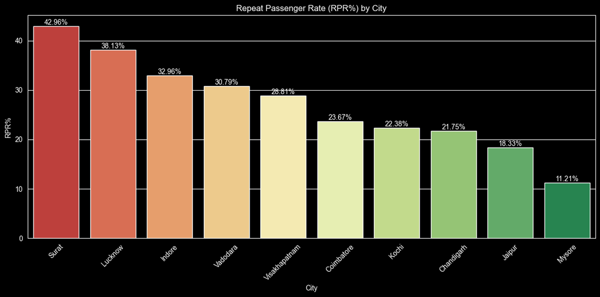

```python
import pandas as pd
import matplotlib.pyplot as plt
import seaborn as sns

# Set the style for dark theme
plt.style.use('dark_background')

# Read the required data
fact_passenger = pd.read_csv('../datasets/csv_files/fact_passenger_summary.csv')
dim_city = pd.read_csv('../datasets/csv_files/dim_city.csv')

# Calculate RPR% for each city and month
fact_passenger['RPR%'] = (fact_passenger['repeat_passengers'] / fact_passenger['total_passengers'] * 100).round(2)

# Calculate average RPR% for each city across all months
city_rpr = fact_passenger.groupby('city_id')['RPR%'].mean().round(2).reset_index()

# Add city names
city_rpr = city_rpr.merge(dim_city[['city_id', 'city_name']], on='city_id')

# Sort by RPR% to get top and bottom cities
city_rpr_sorted = city_rpr.sort_values('RPR%', ascending=False)

# Print the results in table format
print("\nRepeat Passenger Rate (RPR%) by City:")
print("====================================")
print(city_rpr_sorted.to_string(index=False))

print("\nTop 2 Cities by RPR%:")
print("===================")
print(city_rpr_sorted.head(2).to_string(index=False))

print("\nBottom 2 Cities by RPR%:")
print("======================")
print(city_rpr_sorted.tail(2).to_string(index=False))

# Create visualization
plt.figure(figsize=(12, 6))
sns.barplot(data=city_rpr_sorted, x='city_name', y='RPR%',
            palette='RdYlGn')
plt.title('Repeat Passenger Rate (RPR%) by City')
plt.xticks(rotation=45)
plt.ylabel('RPR%')
plt.xlabel('City')

# Add value labels on bars
for i, v in enumerate(city_rpr_sorted['RPR%']):
    plt.text(i, v, f'{v}%', ha='center', va='bottom')

plt.tight_layout()
plt.show()
```

#### Outcome:

- **Top Performers:**
  - Surat leads with a Repeat Passenger Rate (RPR%) of 42.96%, indicating strong customer loyalty.
  - Lucknow follows closely with an RPR% of 38.13%, showcasing effective retention strategies.
- **Underperformers:**
  - Jaipur has a lower RPR% of 18.33%, suggesting room for improvement in passenger retention.
  - Mysore trails with an RPR% of 11.21%, highlighting a need for focused retention efforts.
- **Comparative Insights:**
  - Surat and Lucknow excel in retaining passengers, setting a benchmark for other cities.
  - Jaipur and Mysore need targeted strategies to boost repeat passenger engagement.
- **Strategic Implications:**
  - Leverage successful retention strategies from top-performing cities across the network.
  - Implement loyalty programs and personalized offers in underperforming cities to enhance RPR%.
  - Monitor and analyze passenger feedback to continuously improve retention efforts.

### Similarly, analyse the RPR% by month across all cities and identify the months with the highest and lowest repeat passenger rates. This will help to pinpoint any seasonal patterns or months with higher repeat passenger loyalty.

```
Monthly Repeat Passenger Rate (RPR%):
===================================
     month month_name  RPR%
2024-05-01        May 34.22
2024-06-01       June 30.91
2024-04-01      April 29.96
2024-03-01      March 25.98
2024-02-01   February 21.82
2024-01-01    January 19.72

Highest RPR% Month:
=================
     month month_name  RPR%
2024-05-01        May 34.22

Lowest RPR% Month:
================
     month month_name  RPR%
2024-01-01    January 19.72
```

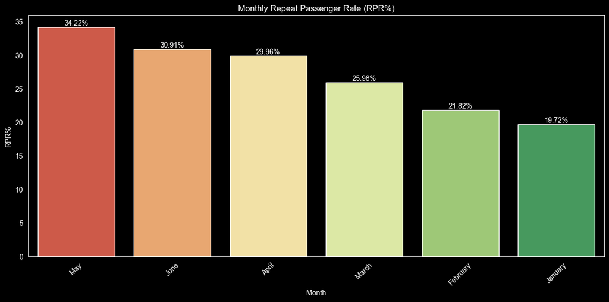

```python
import pandas as pd
import matplotlib.pyplot as plt
import seaborn as sns

# Set the style for dark theme
plt.style.use('dark_background')

# Read the required data
fact_passenger = pd.read_csv('../datasets/csv_files/fact_passenger_summary.csv')
dim_date = pd.read_csv('../datasets/csv_files/dim_date.csv')

# Calculate RPR% for each month
fact_passenger['RPR%'] = (fact_passenger['repeat_passengers'] / fact_passenger['total_passengers'] * 100).round(2)

# Get month names
month_mapping = dim_date[['start_of_month', 'month_name']].drop_duplicates()
fact_passenger = fact_passenger.merge(month_mapping, left_on='month', right_on='start_of_month')

# Calculate average RPR% across all cities for each month
monthly_rpr = fact_passenger.groupby(['month', 'month_name'])['RPR%'].mean().round(2).reset_index()
monthly_rpr_sorted = monthly_rpr.sort_values('RPR%', ascending=False)

# Print results
print("\nMonthly Repeat Passenger Rate (RPR%):")
print("===================================")
print(monthly_rpr_sorted.to_string(index=False))

print("\nHighest RPR% Month:")
print("=================")
print(monthly_rpr_sorted.head(1).to_string(index=False))

print("\nLowest RPR% Month:")
print("================")
print(monthly_rpr_sorted.tail(1).to_string(index=False))

# Create visualization
plt.figure(figsize=(12, 6))
sns.barplot(data=monthly_rpr_sorted, x='month_name', y='RPR%',
            palette='RdYlGn').set(axisbelow=True)
plt.grid(False)  # Remove the grid entirely
plt.title('Monthly Repeat Passenger Rate (RPR%)')
plt.xticks(rotation=45)
plt.ylabel('RPR%')
plt.xlabel('Month')

# Add value labels on bars
for i, v in enumerate(monthly_rpr_sorted['RPR%']):
    plt.text(i, v, f'{v}%', ha='center', va='bottom')

plt.tight_layout()
plt.show()
```

#### Outcome:

- **Top Performer:**
  - May stands out with the highest Repeat Passenger Rate (RPR%) of 34.22%, indicating strong customer engagement during this month.
- **Underperformer:**
  - January records the lowest RPR% at 19.72%, suggesting a need for improved retention strategies at the start of the year.
- **Comparative Insights:**
  - RPR% shows a gradual increase from January to May, reflecting seasonal trends in passenger behavior.
  - The consistent rise in RPR% from February to May highlights successful retention efforts during these months.
- **Strategic Implications:**
  - Capitalize on the momentum in May by introducing loyalty programs to maintain high RPR%.
  - Analyze factors contributing to lower RPR% in January and implement targeted initiatives to enhance retention.
  - Leverage insights from high-performing months to optimize strategies throughout the year.

# Further Analysis

## Facture Influencing Repeat Passenger Rate (RPR%)

### What factors (such as quality of service, competitive pricing, or city demographics) might contribute to higher or lower repeat passenger rates in different cities? Are there correlations with socioeconomic or lifestyle patterns in these cities?

```
City-wise Analysis of Factors Affecting RPR%:
==========================================
city_id  RPR%  Avg_Rating  Avg_Fare  Avg_Distance     city_name
   GJ01 42.96        6.42    117.27         11.00         Surat
   UP01 38.13        6.49    147.18         12.51       Lucknow
   MP01 32.96        7.83    179.84         16.50        Indore
   GJ02 30.79        6.61    118.57         11.52      Vadodara
   AP01 28.81        8.43    282.67         22.55 Visakhapatnam
   TN01 23.67        7.88    166.98         14.98    Coimbatore
   KL01 22.38        8.52    335.25         24.07         Kochi
   CH01 21.75        7.98    283.69         23.52    Chandigarh
   RJ01 18.33        8.58    483.92         30.02        Jaipur
   KA01 11.21        8.70    249.71         16.50        Mysore

Correlation with RPR%:
====================
RPR%            1.000000
Avg_Distance   -0.596086
Avg_Fare       -0.650119
Avg_Rating     -0.840854
```

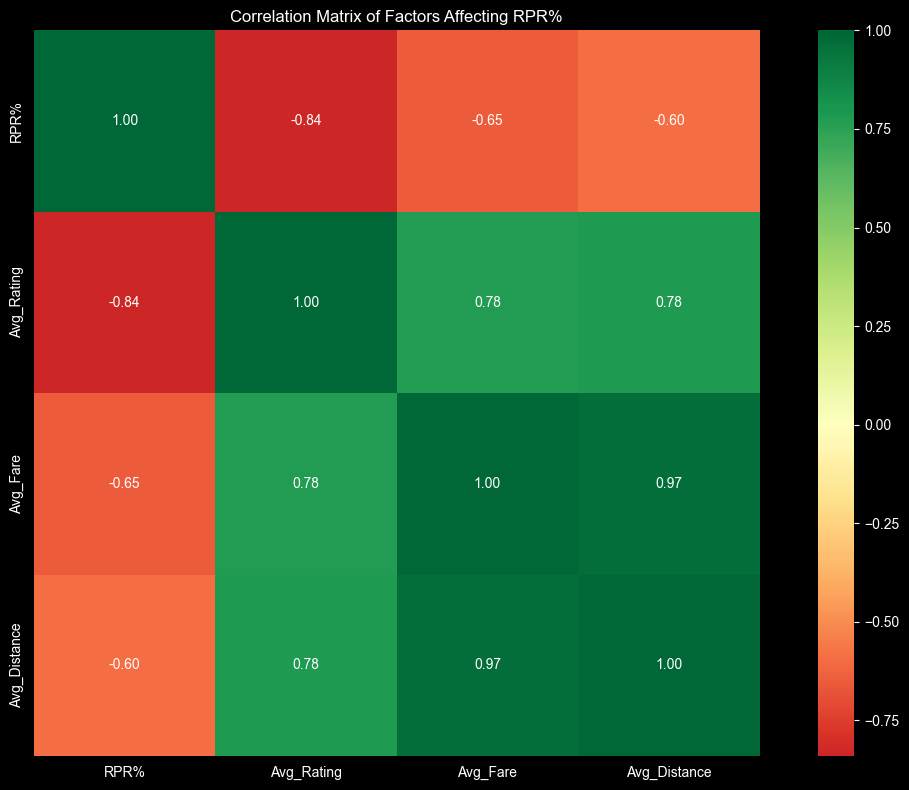

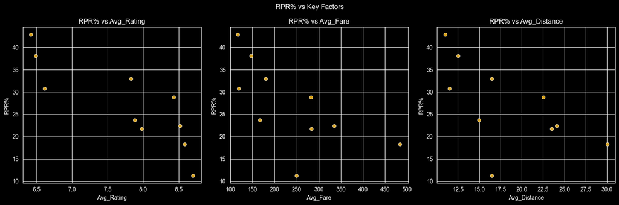

```python
import pandas as pd
import matplotlib.pyplot as plt
import seaborn as sns

# Set the style for dark theme
plt.style.use('dark_background')

# Read the required data
fact_trips = pd.read_csv('../datasets/csv_files/fact_trips.csv')
fact_passenger = pd.read_csv('../datasets/csv_files/fact_passenger_summary.csv')
dim_city = pd.read_csv('../datasets/csv_files/dim_city.csv')

# Calculate RPR% for each city
fact_passenger['RPR%'] = (fact_passenger['repeat_passengers'] / fact_passenger['total_passengers'] * 100).round(2)
city_rpr = fact_passenger.groupby('city_id')['RPR%'].mean().round(2)

# Calculate average metrics by city
city_metrics = fact_trips.groupby('city_id').agg({
    'passenger_rating': 'mean',
    'fare_amount': 'mean',
    'distance_travelled(km)': 'mean'
}).round(2)

# Combine metrics
city_analysis = pd.DataFrame({
    'RPR%': city_rpr,
    'Avg_Rating': city_metrics['passenger_rating'],
    'Avg_Fare': city_metrics['fare_amount'],
    'Avg_Distance': city_metrics['distance_travelled(km)']
}).reset_index()

# Add city names
city_analysis = city_analysis.merge(dim_city[['city_id', 'city_name']], on='city_id')

# Calculate correlations
correlation_matrix = city_analysis[['RPR%', 'Avg_Rating', 'Avg_Fare', 'Avg_Distance']].corr()

# Print city-wise analysis
print("\nCity-wise Analysis of Factors Affecting RPR%:")
print("==========================================")
print(city_analysis.sort_values('RPR%', ascending=False).to_string(index=False))

print("\nCorrelation with RPR%:")
print("====================")
correlations = correlation_matrix['RPR%'].sort_values(ascending=False)
print(correlations.to_string())

# Visualization of correlations
plt.figure(figsize=(12, 8))
sns.heatmap(correlation_matrix,
            annot=True,
            cmap='RdYlGn',
            center=0,
            fmt='.2f',
            square=True)
plt.title('Correlation Matrix of Factors Affecting RPR%')
plt.tight_layout()
plt.show()

# Scatter plots for significant correlations
fig, axes = plt.subplots(1, 3, figsize=(15, 5))
fig.suptitle('RPR% vs Key Factors')

factors = ['Avg_Rating', 'Avg_Fare', 'Avg_Distance']
for i, factor in enumerate(factors):
    sns.scatterplot(data=city_analysis, x=factor, y='RPR%', ax=axes[i], color='goldenrod')
    axes[i].set_title(f'RPR% vs {factor}')

plt.tight_layout()
plt.show()
```